# Data Visualization and Reproducible Research

> Sai Srujana Gunda

Learn more about me in my [GitHub profile page](https://github.com/@saisrujanagunda).

The following is a sample of products created during the *“Data Visualization and Reproducible Research”* course.

## Project 01

In the `project_01/` folder you can *find the analysis focused on the FIFA World Cup data spanning from 1930 to 2014. This comprehensive dataset includes valuable information about players, stadiums, cities, goals, attendance, and more. Through thorough analysis, insights were gained about various aspects of the World Cup, including the winning teams, stadiums, and the attendance recorded in different matches over the years*.

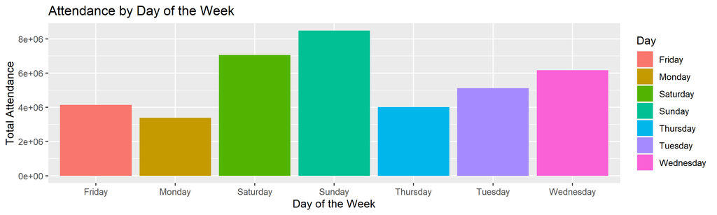

*My favourite visualization*:-

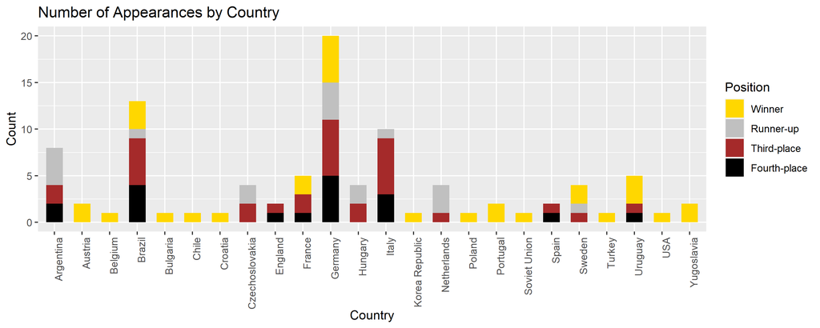

## Project 02

This project delves into the FIFA18 videogame dataset, which encompasses a wide range of variables, including player age, overall rating, potential, and preferred position on the field. Each variable is assigned a specific score, which is used to calculate the overall rating. The analysis revolves around several aspects, such as the number of players in different nations, the overall rating and potential of players, as well as the relationship between these factors.

Find the code and report in the `project_02/` folder.

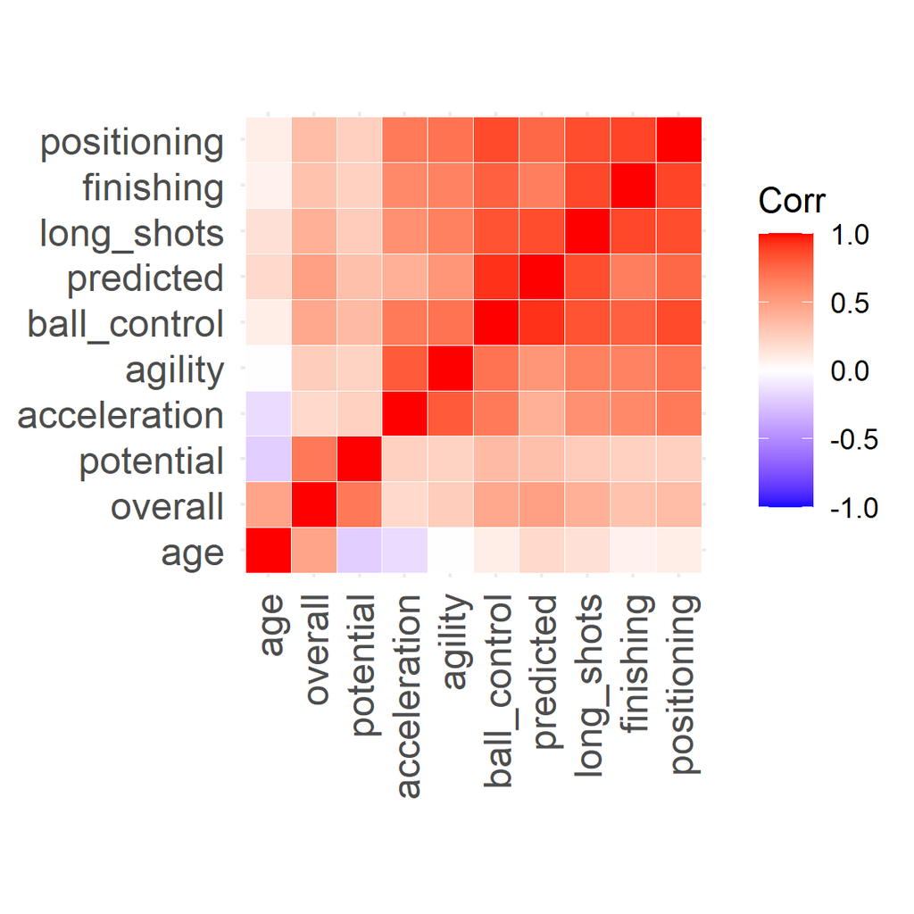

*My favourite visualization*:-

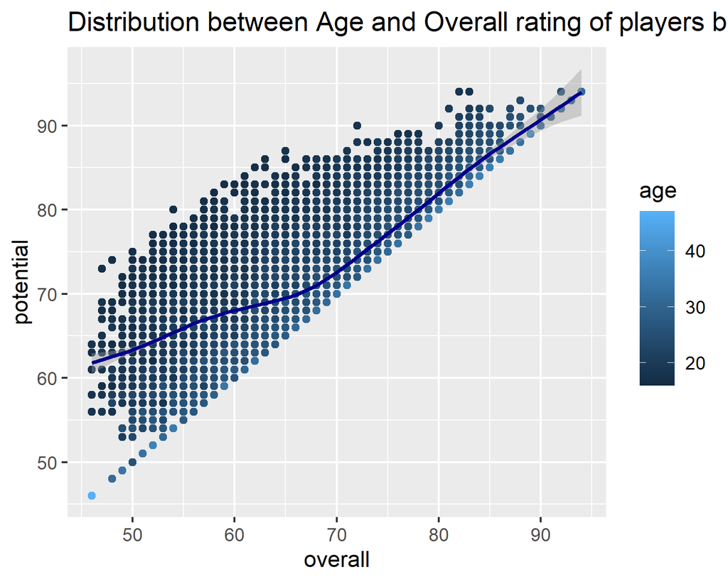

## Project 03

This project consists of two parts. In the first part, I analyzed the daily temperature recordings throughout the year 2022. I explored patterns, trends, and variations in temperature data. In the second part, I focused on text data, specifically the lyrics of songs from the year 2015. I conducted sentiment analysis on the lyrics to determine the overall sentiment expressed in the songs. Additionally, I derived bigrams to identify frequently occurring pairs of words in the lyrics.

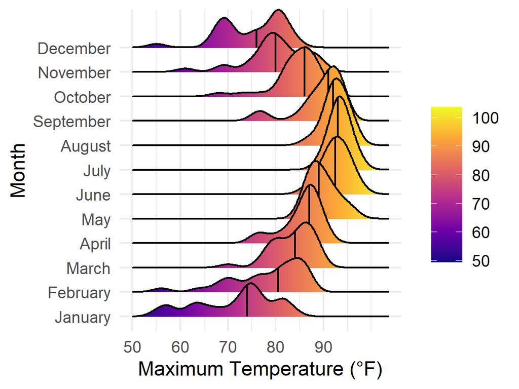

*My favourite visualization is*:-

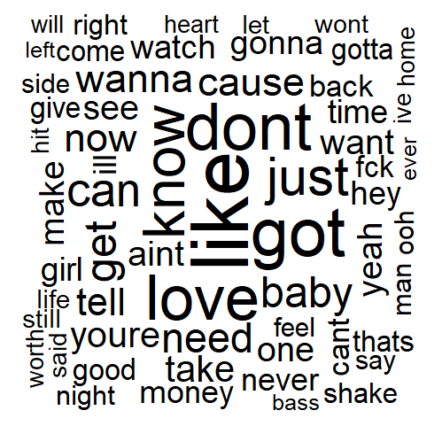

### Moving Forward

Further, I would like to learn about Tableau, Power BI and how the data visualizations produced using R are different from those generated using the tools. Also, I would like to learn better about the interactive plots in R.